# STA 207: Assignment II

Jay Bendre, 920211348

**Instructions**

A consulting firm is investigating the relationship between wages and some demographic factors. The file `Wage.csv` contains three columns, which are

- `wage`, the wage of the subject,
- `ethnicity`, the ethnicity of the subject,
- and `occupation`, the occupation of the subject.

```r
Wage=read.csv('Wage.csv');
library(gplots)
library(lme4)
library(dplyr)
library(stats)
library(knitr)
library(car)
library(tidyverse)
library(broom)
attach(Wage)
df <- Wage
df %>% head()
```

```r
# Performing necessary preprocessing

df$ethnicity <- as.factor(df$ethnicity)
df$occupation <- as.factor(df$occupation)

levels_e <- levels(df$ethnicity)
levels_o <- levels(df$occupation)
len_df <- nrow(df)
```

1. Write down a two-way ANOVA model for this data. For consistency, choose the letters from $\{Y,\alpha, \beta, \mu, \epsilon\}$ and use the factor-effect form.

The 2-way anova model can be described as,

$$Y_{ijk} = \mu + \alpha_{i} + \beta_{j} + (\alpha\beta)_{ij} + \epsilon_{ijk}$$
where,

1. $Y_{ijk}$ = Response variable (Wage)
2. $\mu.. = \sum_{i=1}^{a} \sum_{j=1}^{b}\frac{\mu_{ij}}{(ab)}$ = Population mean or expectation
3. $\alpha_i$ = $\mu_{i.} - \mu..$ = (Cell mean for Ethnicity - Population mean)
4. $\beta_j$ = $\mu_{.j} - \mu..$ = (Cell mean for Occupation - Population mean)
5. $(\alpha\beta)_{ij} = \mu_{ij} - \mu_{i.} - \mu_{.j} + \mu_{..} =$ Represents the interaction terms between cells from occupation and ethnicity
6. $i = {cauc, hispanic, other}$
7. $j = {management, office, sales, services, technical, worker}$
8. $k = 1 .. 534$
9. $\epsilon_{ijk} \sim^{i.i.d} N(0,\sigma^2)$ = Represents the error terms

The following constraints are to be considered in the 2-way anova model.

1. $\sum_{i} \alpha_{i} = \sum_{j} \beta_{j} = 0$
2. $\sum_{i=1}^{3} (\alpha\beta)_{ij} = \sum_{j=1}^{6} (\alpha\beta)_{ij} = 0$
2. Obtain the main effects plots and the interaction plot. Summarize your findings.

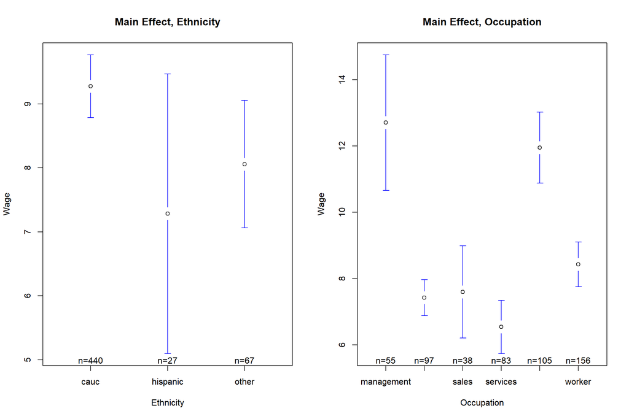

```r
par(mfrow=c(1,2))
plotmeans(wage ~ ethnicity, data = df, xlab = "Ethnicity", ylab = "Wage", main = "Main Effect, Ethnicity",connect = FALSE)
plotmeans(wage ~ occupation, data = df, xlab = "Occupation", ylab = "Wage",main = "Main Effect, Occupation", connect = FALSE)
```

On observing the individual effects of **ethnicity** and **occupation** we can see that there is a difference in the cell means for every factor value corresponding in either of the variables. In left we can see the effect plot of ethinicity where we observe that there is a disparity in the salaries between **caucasian** and **hispanic** employees, caucasian employees having higher salaries than hispanic employees. However, the confidence intervals for hispanic employees is very wide making it seem like the sample size for hispanic employees may be smaller ie. unbalanced classes.

In the right graph we can see that the specific occupation is responsible for changing the mean salary. Occupations in **management** seem to have significantly higher wages as opposed to occupations in **services**. Occupations in **technical** seem to have the second highest wages after management.

To test for the interaction term, we need to use an interaction plot

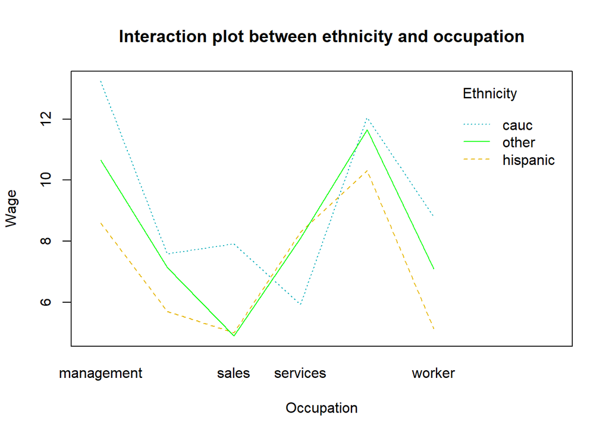

```r
interaction.plot(df$occupation, df$ethnicity, df$wage, ylab = "Wage", xlab = "Occupation", main = "Interaction plot between ethnicity and occupation", col = c("#00AFBB", "#E7B800", "#00FF00"), trace.label = "Ethnicity")
```

From the above plot we can see a consistent trend that **caucasian** employees have higher wages in all occupation domains except in **services**. In the **services** department, **hispanic** employees seem to get paid on average more than caucasian employees. The significant difference in the means based on race and occupation is indicative of the fact that the interaction term is significant in the analysis.

3. Fit the ANOVA model described in Part 1. Obtain the ANOVA table and state your conclusions. Are the findings here consistent with your initial assessments from Part 2?

```r
# Fitting an anova model
full.model <- aov(wage ~ ethnicity + occupation + occupation:ethnicity, data = df)
summary(full.model)
```

```
##                       Df Sum Sq Mean Sq F value Pr(>F)
## ethnicity              2    173    86.3   3.986 0.0191 *
## occupation             5   2459   491.7  22.704 <2e-16 ***
## ethnicity:occupation  10    270    27.0   1.247 0.2579
## Residuals            516  11175    21.7
## ---
## Signif. codes:  0 '***' 0.001 '**' 0.01 '*' 0.05 '.' 0.1 ' ' 1
```

Explaining the output of the 2-way anova model:

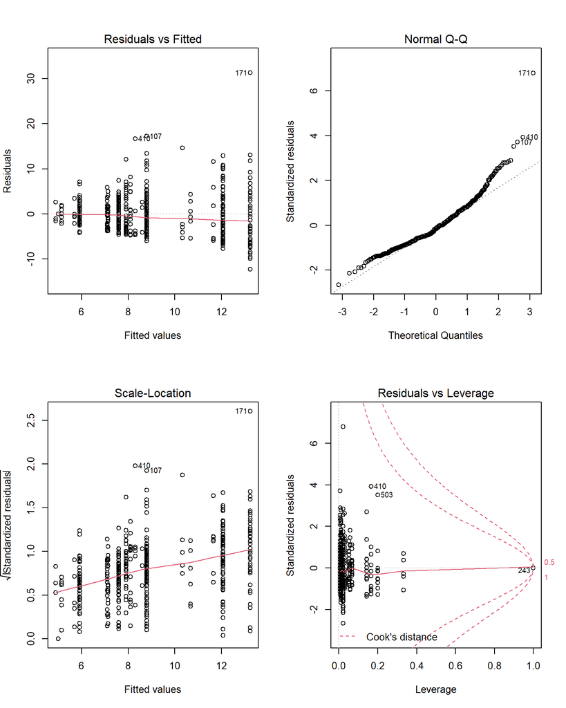

```r
# Diagnostic Plots
par(mfrow = c(2,2))
plot(full.model)
```

We can perform the Levene’s test for equal variances and then check for normality of residuals using the Shapiro-Wilk test.

```r
leveneTest(wage ~ ethnicity * occupation, data = df)
```

```
## Levene's Test for Homogeneity of Variance (center = median)
##        Df F value    Pr(>F)
## group  17  4.4859 9.188e-09 ***
##       516
## ---
## Signif. codes:  0 '***' 0.001 '**' 0.01 '*' 0.05 '.' 0.1 ' ' 1
```

```r
shapiro.test(aov(wage ~ ethnicity + occupation + occupation:ethnicity, data = df)$residuals)
```

```
##
##  Shapiro-Wilk normality test
##
## data:  aov(wage ~ ethnicity + occupation + occupation:ethnicity, data = df)$residuals
## W = 0.92822, p-value = 2.648e-15
```

4. Carry out a test to decide if the effect of ethnicity is present on the full data set, at the significance level $\alpha=0.01$.

In order to check whether the effect is significant we can conduct a F-test.

$H_0: \alpha_i = 0 , ∀ i \in [1,3]$

$H_a:$ not all $\alpha_i = 0$

The testing condition is that we reject $H_0$ if $P(F^* > F_{critical}) \leq \alpha$

5. For this part and the next, assume that the occupations have been selected randomly. Write down an appropriate ANOVA model that is additive in the factors and explain the terms in the model.

The 2-way anova model that could be fit here can be described as:

$$Y_{ijk} = \mu_{..} + \alpha_{i.} + \beta_{.j} + \epsilon_{ijk}$$

with the same variable definitions as mentioned in the Question 1 such that

$$\sum_i \alpha_i = 0$$

$$\epsilon_{ijk} \sim N(0,\sigma^2)$$

where,

1. $Y_{ijk}$ = Response variable (Wage)
2. $\mu.. = \sum_{i=1}^{a} \sum_{j=1}^{b}\frac{\mu_{ij}}{(ab)}$ = Population mean or expectation
3. $\alpha_{i.}$ = $\mu_{i.} - \mu..$ = (Cell mean for Ethnicity - Population mean)
4. $\beta_{.j} \sim^{i.i.d} N(0,\sigma^2_{\beta})$
5. $i = {cauc, hispanic, other}$
6. $j = {management, office, sales, services, technical, worker}$
7. $k = 1 .. 534$

Since we have mixed effects, $E[Y_{ijk}] = \mu_{..} + \alpha_{i}$, where $\alpha_i$ shows up because its a fixed effect. Also, $\epsilon_{ijk}$ and $\beta_j$ are pairwise independent.

```r
# Fitting a model only with the additive terms
options(contrasts = c("contr.treatment", "contr.poly"))
reduced.model <-aov(wage ~ ethnicity + occupation, data = df)
summary(reduced.model)
```

```
##              Df Sum Sq Mean Sq F value Pr(>F)
## ethnicity     2    173    86.3   3.967 0.0195 *
## occupation    5   2459   491.7  22.598 <2e-16 ***
## Residuals   526  11445    21.8
## ---
## Signif. codes:  0 '***' 0.001 '**' 0.01 '*' 0.05 '.' 0.1 ' ' 1
```

6. Assuming that the model in Part 5 is appropriate, obtain an estimate of the proportion of variability that is due to variability in occupation.

```r
summary(lmer(wage ~ ethnicity + (1|occupation), data = df))
```

```
## Linear mixed model fit by REML ['lmerMod']
## Formula: wage ~ ethnicity + (1 | occupation)
##    Data: df
##
## REML criterion at convergence: 3171.8
##
## Scaled residuals:
##     Min      1Q  Median      3Q     Max
## -2.4974 -0.6629 -0.1867  0.4927  6.8278
##
## Random effects:
##  Groups     Name        Variance Std.Dev.
##  occupation (Intercept)  6.205   2.491
##  Residual               21.760   4.665
## Number of obs: 534, groups:  occupation, 6
##
## Fixed effects:
##                   Estimate Std. Error t value
## (Intercept)         9.2654     1.0451   8.865
## ethnicityhispanic  -1.8077     0.9265  -1.951
## ethnicityother     -0.5760     0.6175  -0.933
##
## Correlation of Fixed Effects:
##             (Intr) ethnctyh
## ethnctyhspn -0.051
## ethnictythr -0.077  0.093
```

The ratio of variances = $0.2218845$

Another metric is given by,
$$\frac{s^2_{\mu}}{(s^2_{\mu} + MSE)}$$

where $s^2_{\mu} = MSTR - MSE/n$ from the ANOVA model fitted.

```r
s2_mu <- (491.7 - 21.8)/534
s2_mu/(s2_mu + 21.8)
```

```
## [1] 0.03879912
```

One way of determining would be to find the partial $R^2$ for the model.

That is given by
$$R^2_{partial} = \frac{SSE_{reduced} - SSE_{full}}{SSE_{reduced}}$$

```r
model.eth <- aov(wage ~ ethnicity, data = df)
model.no_interact <- aov(wage ~ ethnicity + occupation, data = df)

reduced_sse <- model.eth %>% tidy() %>% filter(term == "Residuals") %>% select(sumsq) %>% pull()

full_sse <- model.no_interact %>% tidy() %>% filter(term == "Residuals") %>% select(sumsq) %>% pull()

partial_r2 <- (reduced_sse - full_sse)/reduced_sse
```

From the calculations, we get $R_{partial}^2 = 0.176824$

## Acknowledgement

Help taken from the team mates assigned in the roster.

Resources accessed for the assignment:

1. For $\omega^2$ https://onlinestatbook.com/2/effect_size/variance_explained.html